# Problem Set 05

Lauren Sullivan, BIO_SC 8002_01

Due Mar 18, 2022

## Temperature Sex Determination

### Non-Normal Models

First we will look at a dataset of the sex ratio of turtles on islands in the Mississippi river with “ratio.csv”. Researchers sampled 12 turtle nests in each of 4 islands, measured the temperature of each nest, and then counted the number of male (1) and female (0) turtle babies in each nest. Each nest amazingly had exactly 20 baby turtles each! Assume nests are independent, and there are no differences among nests other than the islands they are found on, and the temperature of each nest. Nests can have different temperatures because of where females lay them (in the shade or in the sun).

```r
###############
#
# 05 PROBLEM SET
#
# DUE:        March 18, 2022
#
# CREATED BY: Lauren Sullivan
# FILES:      "ratio.csv"
#             "mass.csv"
#
###############


########### setup
rm(list=ls())

#setwd("~/Dropbox/Academics/Teaching/Advanced Quant Methods/modules/2) linear_nonlinear_mixedeffects/5_nonlinear_nonnormal")
library(tidyverse)
library(stats)  #for nls()
library(bbmle)  #for AICtab()

########### data
ratio <- read_csv("../data/ratio.csv")
mass <- read_csv("../data/mass.csv")
```

**Q1** What is a good distribution to describe the dependent variable (here: number of males vs females in each nest)? What is the support of this distribution? What is it’s functional form and what does it mean?

```r
##  This is 0/1 data, so it is best described by a binomial distribution

## support: 1, 2, 3, 4, all whole numbers

## PMF: $$\binom{n}{k} = \frac{n!}{k!(n-k)!}$$

#   This means that n successful trials out of k total trials equals the
#     fraction of n! over k!(n-k!) and that's the proportion of successful
#     trials. (So here it's the number of males out of the total)
```

**Q2** Before analyzing the data, let’s visualize it. Create a figure of the per nest male-to-female ratio, and how that dependent variable varies by temperature and island. What trends jump out at you right away re: the relationship between $Y$ and the $X$’s?

```r
ratio_2 <- ratio %>%
            mutate(., no_male = rowSums(.[4:23]),
                   total = 20,
                   no_female = total - no_male,
                   sex_ratio = no_male/total)
ratio_2
```

```
## # A tibble: 48 × 27
##    island  tempe…¹ sunfl…²  egg1  egg2  egg3  egg4  egg5  egg6  egg7  egg8  egg9
##    <chr>     <dbl>   <dbl> <dbl> <dbl> <dbl> <dbl> <dbl> <dbl> <dbl> <dbl> <dbl>
##  1 apple      9.42   15.8      0     1     1     0     1     1     0     1     1
##  2 campbe…   10.2    10.8      1     1     1     0     1     1     1     0     1
##  3 blanch…   13.1    13.8      1     1     1     1     1     1     0     1     1
##  4 davis     13.1    13.1      0     1     1     1     1     1     0     1     1
##  5 apple     13.2    11.1      1     1     1     1     1     1     1     0     1
##  6 apple     14.1     9.95     1     0     0     1     0     0     1     1     1
##  7 blanch…   14.6     9.60     1     0     1     0     1     1     0     1     1
##  8 apple     15.1     8.82     0     1     0     0     1     0     0     0     0
##  9 campbe…   15.3     9.57     1     1     1     0     0     0     0     1     0
## 10 davis     15.6     9.49     0     1     1     1     1     1     1     0     1
## # … with 38 more rows, 15 more variables: egg10 <dbl>, egg11 <dbl>,
## #   egg12 <dbl>, egg13 <dbl>, egg14 <dbl>, egg15 <dbl>, egg16 <dbl>,
## #   egg17 <dbl>, egg18 <dbl>, egg19 <dbl>, egg20 <dbl>, no_male <dbl>,
## #   total <dbl>, no_female <dbl>, sex_ratio <dbl>, and abbreviated variable
## #   names ¹temperature, ²sunflecks
```

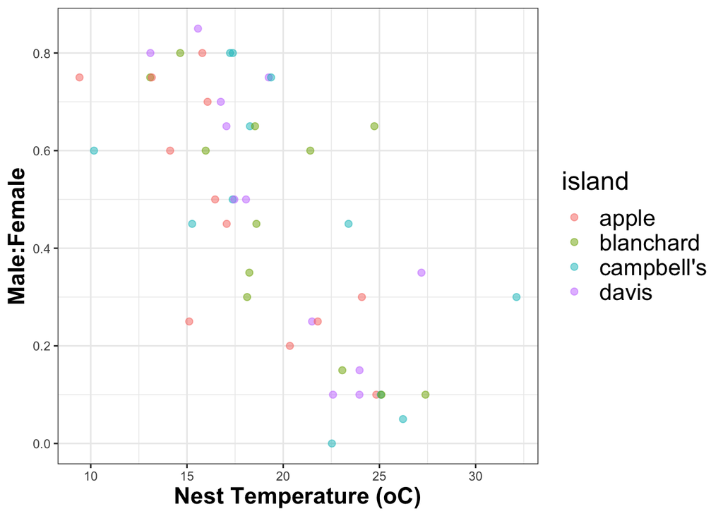

```r
ggplot(ratio_2)+
  geom_point(aes(x = temperature, y = sex_ratio, color = island),
             alpha = 0.5, cex = 2)+
  theme_bw()+
  theme(axis.title = element_text(face="bold", size=16),
         legend.text = element_text(size = 16),
         legend.title = element_text(size = 18))+
  labs(x = "Nest Temperature (oC)", y = "Male:Female")
```

```r
## looks like there is a strong negative trend of sex ratio
#     with temperature. But there are no differences among
#     islands.
```

**Q3** How would you confirm your suspicions about islands graphically?

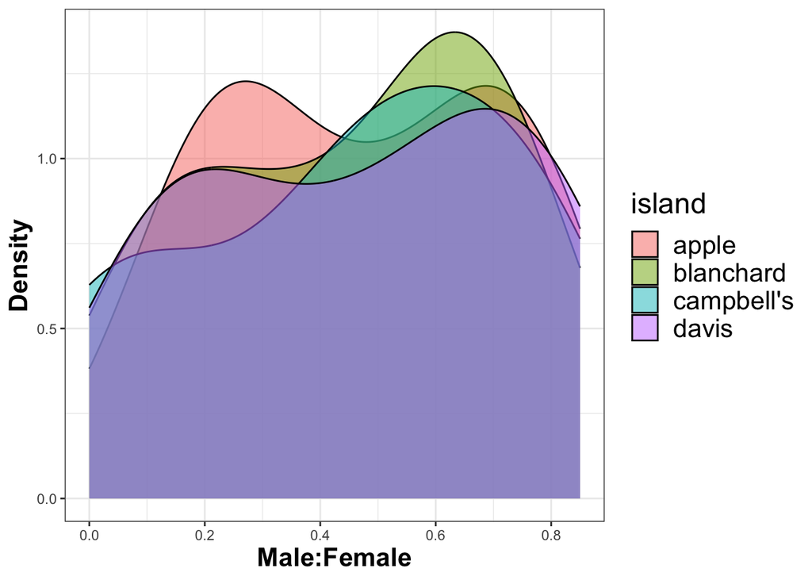

```r
ggplot(ratio_2)+
  geom_density(aes(x = sex_ratio, fill = island), alpha = 0.5)+
  theme_bw()+
  theme(axis.title = element_text(face="bold", size=16),
         legend.text = element_text(size = 16),
         legend.title = element_text(size = 18))+
  labs(x = "Male:Female", y = "Density")
```

```r
## the density plot shows there really isn't a difference in the
#     distributions of the data among islands.  Maybe Apple Island
#     has a slightly more female biased population.
```

**Q4** Run the statistical test that will determine the effect of island identity and temperature on the sex ratio of these islands using the appropriate `glm()`. What does this data tell us about these turtle nests? Hint: The response variable ($Y$) should be classified as a cbind() of the number of males and the number of not males (aka females) with binomial distribution. [See the “Details” section on how to parameterize binomial and quasibinomial models here.](https://www.rdocumentation.org/packages/stats/versions/3.6.2/topics/glm)

```r
test4a <- glm(cbind(no_male, no_female) ~ island + temperature,
              family = "binomial", data = ratio_2)
summary(test4a)
```

```
##
## Call:
## glm(formula = cbind(no_male, no_female) ~ island + temperature,
##     family = "binomial", data = ratio_2)
##
## Deviance Residuals:
##     Min       1Q   Median       3Q      Max
## -4.1106  -1.4898  -0.2554   1.2524   3.7372
##
## Coefficients:
##                  Estimate Std. Error z value Pr(>|z|)
## (Intercept)       3.04846    0.32512   9.376   <2e-16 ***
## islandblanchard   0.41521    0.20074   2.068   0.0386 *
## islandcampbell's  0.45200    0.20414   2.214   0.0268 *
## islanddavis       0.45531    0.19939   2.283   0.0224 *
## temperature      -0.18391    0.01728 -10.646   <2e-16 ***
## ---
## Signif. codes:  0 '***' 0.001 '**' 0.01 '*' 0.05 '.' 0.1 ' ' 1
##
## (Dispersion parameter for binomial family taken to be 1)
##
##     Null deviance: 283.04  on 47  degrees of freedom
## Residual deviance: 145.32  on 43  degrees of freedom
## AIC: 302.93
##
## Number of Fisher Scoring iterations: 4
```

```r
test4b <- glm(sex_ratio ~ island + temperature, family = "binomial",
              data = ratio_2)
summary(test4b)
```

```
##
## Call:
## glm(formula = sex_ratio ~ island + temperature, family = "binomial",
##     data = ratio_2)
##
## Deviance Residuals:
##     Min       1Q   Median       3Q      Max
## -0.9192  -0.3331  -0.0571   0.2801   0.8357
##
## Coefficients:
##                  Estimate Std. Error z value Pr(>|z|)
## (Intercept)       3.04846    1.45399   2.097   0.0360 *
## islandblanchard   0.41521    0.89774   0.463   0.6437
## islandcampbell's  0.45200    0.91293   0.495   0.6205
## islanddavis       0.45531    0.89172   0.511   0.6096
## temperature      -0.18391    0.07726  -2.380   0.0173 *
## ---
## Signif. codes:  0 '***' 0.001 '**' 0.01 '*' 0.05 '.' 0.1 ' ' 1
##
## (Dispersion parameter for binomial family taken to be 1)
##
##     Null deviance: 14.1522  on 47  degrees of freedom
## Residual deviance:  7.2661  on 43  degrees of freedom
## AIC: 59.69
##
## Number of Fisher Scoring iterations: 4
```

```r
##  You can see that if you just use the "ratio" for your Y you get similar results.  But
#     the number of males vs the number of not males (aka females) (test 4a) more
#     accurately reflects how this distribution works and thus is the appropriate formulation.
```

### Determining Functional Forms

**Q5** It seems like sunflecks might be a good predicter of nest temperature, but we are not sure what the shape of that relationship is. Plot this relationship.

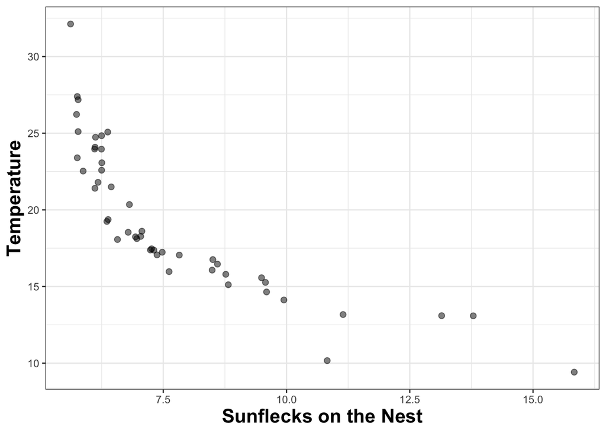

```r
ggplot(ratio_2)+
  geom_point(aes(x = sunflecks, y = temperature),
             alpha = 0.5, cex = 2)+
  theme_bw()+
  theme(axis.title = element_text(face="bold", size=16),
         legend.text = element_text(size = 16),
         legend.title = element_text(size = 18))+
  labs(x = "Sunflecks on the Nest", y = "Temperature")
```

**Q6** Fit $Y$ (temperature) as a function of $X$ (sunflecks) to find out if there is a significant relationship between these two variables. To do this, compare a linear, exponential, quadratic, and a power relationship. Hint: for your exponential function, try $Y = a * exp(-b*X)$, and your power function try $Y = a * X^b$. What are the coefficients from the resulting best fit model?

```r
fit_linear <- lm(temperature ~ sunflecks, data = ratio_2)

fit_exp <- nls(temperature ~ a * exp(-b * sunflecks),
                      data = ratio_2, start = list(a = 1, b = .2))

fit_quad <- nls(temperature ~ a * sunflecks^2 + b * sunflecks,
                data = ratio_2, start = list(a = 0 , b = 0))

fit_power<- nls(temperature ~ a * sunflecks^b,
                      data = ratio_2, start = list(a = 5, b = -.2))



AICtab(fit_linear, fit_exp, fit_quad, fit_power)
```

```
##            dAIC df
## fit_power   0.0 3
## fit_exp    15.5 3
## fit_linear 32.5 3
## fit_quad   83.9 3
```

```r
## The coefficients are:

coefficients(fit_power)
```

```
##         a         b
## 172.39402  -1.10897
```

**Q7** Plot the relationship between sunflecks and temperature, and include the predicted fits from all of the models you tried and compared?

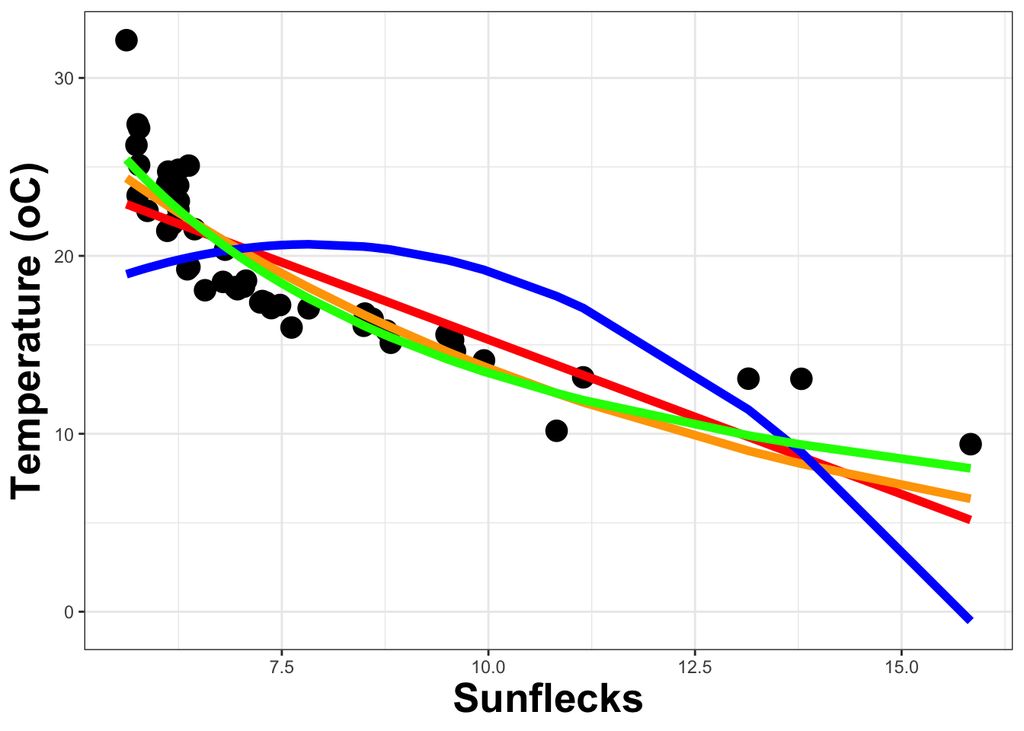

```r
ggplot(ratio_2, aes(x = sunflecks, y = temperature))+
  geom_point(aes(cex = 2))+
  geom_line(aes(x = sunflecks, y = predict(fit_linear, data.frame(sunflecks))),
            color = "red", lwd = 2)+
  geom_line(aes(x = sunflecks, y = predict(fit_exp, data.frame(sunflecks))),
            color = "orange", lwd = 2)+
  geom_line(aes(x = sunflecks, y = predict(fit_quad, data.frame(sunflecks))),
            color = "blue", lwd = 2)+
  geom_line(aes(x = sunflecks, y = predict(fit_power, data.frame(sunflecks))),
            color = "green", lwd = 2)+
  theme_bw()+
  theme(axis.title = element_text(face="bold", size=20))+
  labs(x = "Sunflecks", y = "Temperature (oC)")+
  theme(legend.position = "none")
```

## Gecko Body Mass

### Fitting Distribtuions

Ok, now we are going to practice fitting distributions to our data using `mle2()`. We will practice with a dataset of body mass of geckos. We have 50 animals, and their bodymass, in “mass.csv”.

**Q8** Create a density plot of the bodymass data.

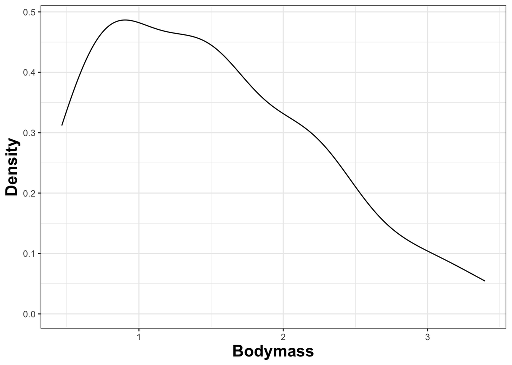

```r
ggplot(mass)+
  geom_density(aes(x = body_mass))+
  theme_bw()+
  theme(axis.title = element_text(face="bold", size=16),
         legend.text = element_text(size = 16),
         legend.title = element_text(size = 18))+
  labs(x = "Bodymass", y = "Density")
```

**Q9** Since the distribution seems to be continuous, try fitting a gaussian, a gamma, and a weibull distribution to the data and see which fits best of those three. Hint: you will need `library("stats")` for some of these distributions.

```r
fit.norm <- mle2(mass$body_mass~dnorm(mean=mu, sd=s),
                      start=list(mu=mean(mass$body_mass),
                                 s=sd(mass$body_mass)),
                      data=mass)
summary(fit.norm)
```

```
## Maximum likelihood estimation
##
## Call:
## mle2(minuslogl = mass$body_mass ~ dnorm(mean = mu, sd = s), start = list(mu = mean(mass$body_mass),
##     s = sd(mass$body_mass)), data = mass)
##
## Coefficients:
##    Estimate Std. Error z value     Pr(z)
## mu  1.48916    0.10454  14.245 < 2.2e-16 ***
## s   0.73920    0.07392  10.000 < 2.2e-16 ***
## ---
## Signif. codes:  0 '***' 0.001 '**' 0.01 '*' 0.05 '.' 0.1 ' ' 1
##
## -2 log L: 111.6748
```

```r
fit.gamma <- mle2(mass$body_mass~dgamma(shape=shape, rate=rate),
                      start=list(shape=mean(mass$body_mass),
                                 rate=sd(mass$body_mass)),
                      data=mass)
summary(fit.gamma)
```

```
## Maximum likelihood estimation
##
## Call:
## mle2(minuslogl = mass$body_mass ~ dgamma(shape = shape, rate = rate),
##     start = list(shape = mean(mass$body_mass), rate = sd(mass$body_mass)),
##     data = mass)
##
## Coefficients:
##       Estimate Std. Error z value     Pr(z)
## shape  3.96287    0.76157  5.2036 1.955e-07 ***
## rate   2.66114    0.54523  4.8808 1.057e-06 ***
## ---
## Signif. codes:  0 '***' 0.001 '**' 0.01 '*' 0.05 '.' 0.1 ' ' 1
##
## -2 log L: 103.9104
```

```r
fit.weibull <- mle2(mass$body_mass~dweibull(shape=shape, scale=scale),
                      start=list(shape=mean(mass$body_mass),
                                 scale=sd(mass$body_mass)),
                      data=mass)

summary(fit.weibull)
```

```
## Maximum likelihood estimation
##
## Call:
## mle2(minuslogl = mass$body_mass ~ dweibull(shape = shape, scale = scale),
##     start = list(shape = mean(mass$body_mass), scale = sd(mass$body_mass)),
##     data = mass)
##
## Coefficients:
##       Estimate Std. Error z value     Pr(z)
## shape  2.16134    0.23658  9.1358 < 2.2e-16 ***
## scale  1.68867    0.11684 14.4529 < 2.2e-16 ***
## ---
## Signif. codes:  0 '***' 0.001 '**' 0.01 '*' 0.05 '.' 0.1 ' ' 1
##
## -2 log L: 105.1934
```

```r
AICtab(fit.norm, fit.gamma, fit.weibull)
```

```
##             dAIC df
## fit.gamma   0.0  2
## fit.weibull 1.3  2
## fit.norm    7.8  2
```

```r
## Gamma and Weibull distn. fit fit equally well based on AIC.
#   Because these two distributions are within 2 AIC points, you
#   can't say they fit the data differently.  But both fit
#   the data better than the normal distribution.
```

**Q10** Plot your data and the fit distributions to confirm your AIC results.

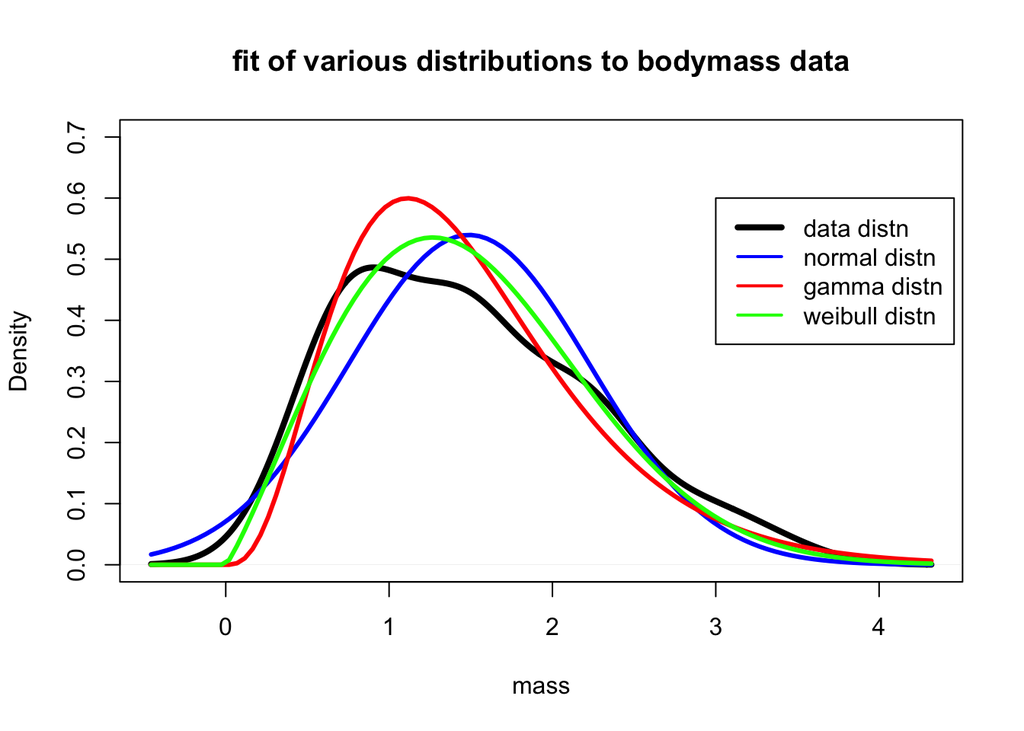

```r
mu.mle.norm<-coef(fit.norm)[[1]]
sd.mle.norm<-coef(fit.norm)[[2]]
shape.mle.gamma<-coef(fit.gamma)[[1]]
rate.mle.gamma<-coef(fit.gamma)[[2]]
shape.mle.weibull<-coef(fit.weibull)[[1]]
scale.mle.weibull<-coef(fit.weibull)[[2]]

par(mfrow=c(1,1))
plot(density(mass$body_mass),xlab='mass',lwd=4,ylim=c(0,.7), main="fit of various distributions to bodymass data")
curve(dnorm(x,mean=mu.mle.norm,sd=sd.mle.norm),col='blue',lwd=3,add=T)
curve(dgamma(x,shape = shape.mle.gamma, rate=rate.mle.gamma),col='red',lwd=3,add=T)
curve(dweibull(x,shape=shape.mle.weibull, scale = scale.mle.weibull),col='green',lwd=3, add=T)
legend(3,.6,legend=c('data distn','normal distn','gamma distn', 'weibull distn'),lty=1,col=c('black','blue','red', "green"),lwd=c(4,2,2,2))
```